Parkinsons Disease Prediction

Author: Suresh Venkatesan

Objective: Classify a patient as normal or having Parkinson's disease based on multiple attributes from their voice recordings

# Import necessary libraries

```python
import numpy as np
import pandas as pd
import matplotlib.pyplot as plt
import matplotlib as mpl
import seaborn as sns
import time
sns.set(color_codes = True)
%matplotlib inline

from scipy import stats

# Preprocessing libraries
from sklearn.preprocessing import MinMaxScaler # MinMax Scaler
from sklearn.preprocessing import StandardScaler # Standard Scaler
from sklearn.preprocessing import RobustScaler # Robust Scaler

# Model libraries
from sklearn.dummy import DummyClassifier # Dummy classifier
from sklearn.linear_model import LogisticRegression # Logistic Regression Classifier
from sklearn.neighbors import KNeighborsClassifier # KNN classifier
from sklearn.naive_bayes import GaussianNB # Gaussian Naive Bayes classifier
from sklearn.naive_bayes import BernoulliNB # Bernoulli Naive Bayes classifier
from sklearn.svm import LinearSVC # Linear Support Vector Classifier
from sklearn.svm import SVC # Support Vector Machine classifer
from sklearn.tree import DecisionTreeClassifier # Decision tree classifier
from sklearn.ensemble import BaggingClassifier # Bagging Classifier
from sklearn.ensemble import RandomForestClassifier # Random Forest Classifier
from sklearn.ensemble import AdaBoostClassifier # Adaptive Boosting Classifier
from sklearn.ensemble import GradientBoostingClassifier # Gradient Boosting Classifier
from sklearn.ensemble import StackingClassifier # Stacking Classifier

# Model selection libraries
from sklearn.model_selection import train_test_split # Split data into training and test sets
from sklearn.model_selection import GridSearchCV # Exhaustive grid search on hyper parameters.
from sklearn.model_selection import RandomizedSearchCV # Randomized search on hyper parameters.

# Metric evaluation libraries
from sklearn.metrics import confusion_matrix # Compute confusion matrix.
from sklearn.metrics import f1_score # Compute f1 score.
from sklearn.metrics import classification_report # Generate classification report.
from sklearn.metrics import accuracy_score # Classification accuracy metric
from sklearn.metrics import precision_recall_curve # Plot recall vs. precision curve
from sklearn.metrics import average_precision_score # Compute average precision score.
from sklearn.metrics import roc_curve # Plot ROC curve
from sklearn.metrics import roc_auc_score # Compute AUC score

# Pipelines
from sklearn.pipeline import Pipeline # Build pipelines
from sklearn.pipeline import make_pipeline # Construct a Pipeline from the given estimators.
```

```python
# Set some plotting and printing ptions
mpl.rc('axes', labelsize = 30)
mpl.rc('axes', titlesize = 30)
mpl.rc('xtick', labelsize = 20)
mpl.rc('ytick', labelsize = 20)
mpl.rc('legend', fontsize = 20)
mpl.rc('figure', titlesize = 40)

pd.set_option('precision', 4) # Print 4 decimal places for all output parameters
```

# Helper Functions

- In this section, we will define multiple helper functions which will be used later in the code for fitting models, evaluating and plotting various metrics.

## Five-Point Summary, Outliers, Skew

- This function will print a summary of the five-point summary, number of outliers and skew of all numeric columns.

```python
def fps_out_skew(df_orig, numer_cols):

    """
    Function to print summary of the five-point summary, number of outliers
    and skew of all numeric columns.

    Arguments:
        df_orig - Input Dataframe.
        numer_cols - List of all numeric columns.

    Returns:
        fps_out_skew_df - Dataframe with summary of the five-point summary, number of outliers
                          and skew of all numeric columns.

    """


    fps_out_skew_df = df_orig[numer_cols].quantile(q = [0, 0.25, 0.5, 0.75, 1], axis = 0).transpose()
    quart_cols = {0.00: "Min", 0.25: 'Q1', 0.5: "Q2", 0.75: "Q3", 1.00: "Max"}
    fps_out_skew_df.rename(columns = quart_cols, inplace = True)
    fps_out_skew_df['IQR'] = fps_out_skew_df['Q3'] - fps_out_skew_df['Q1']
    fps_out_skew_df['skew'] = stats.skew(df_orig[numer_cols])
    fps_out_skew_df['out_low'] = 0
    fps_out_skew_df['out_high'] = 0
    out_min_thresh = fps_out_skew_df['Q1'] - 1.5 * fps_out_skew_df['IQR']
    out_max_thresh = fps_out_skew_df['Q3'] + 1.5 * fps_out_skew_df['IQR']
    for col in numer_cols:
        fps_out_skew_df.loc[col, 'out_low'] = ((df_orig[col] < out_min_thresh[col]).sum())
        fps_out_skew_df.loc[col, 'out_high'] = ((df_orig[col] > out_max_thresh[col]).sum())

    fps_out_skew_df['out_tot'] = fps_out_skew_df['out_low'] + fps_out_skew_df['out_high']

    return fps_out_skew_df
```

## Init classifier dictionary function

- This function is used to define all classifiers and collect them together into a dictionary. The following classifiers are evaluated here:
  - **Logistic Regression.**
  - **Logistic Regression with balanced class weights.**
  - **Gaussian Naive Bayes model.**
  - **KNN classifier.**
  - **Linear Support vector classifier.**
  - **Support Vector Machine classifier with Polynomial Kernel.**
  - **Support Vector Machine Classifier with RBF Kernel.**
  - **Decision Tree Classifier.**
  - **Bagging Classifier.**
  - **Random Forest Classifier.**
  - **Adaptive Boosting Classifier.**
  - **Gradient Boosting Classifier.**

```python
def clf_define():

    """
    Function to define all classifiers and collect into a dictionary

    Arguments:
        None

    Returns:
        clfs - Dictionary of classifiers.
               Key of clfs = S.No of classifier
               Each entry of clfs is a list with the classifier object,
               name of the classifier, type of the classifier,
               coarse parameter list to do grid search,
               fine parameter list to do grid search.

    """
    clf_ind = -1 # Initialize index of classifiers
    clfs = dict() # Initialize dictionary of classifiers
    clf = [] # List to store classifier objects
    clf_name = [] # List to store classifier names
    clf_type = [] # List to store classifier types

    # Logistic regression with equal weights for all classes.
    clf_ind += 1
    clf.append(LogisticRegression(solver = 'liblinear'))
    clf_name.append('Logistic_Regression_Without_Class_Weights')
    clf_type.append('Linear')
    param_grid_coarse = {'C': [0.01, 0.05, 0.1, 0.5, 1, 5, 10, 25, 50, 75, 100, 500, 1000]}
    param_grid_fine = {'C': list(range(1, 11, 1))}
    clfs.update({clf_ind: [clf[clf_ind], clf_name[clf_ind], clf_type[clf_ind],\
                             param_grid_coarse, param_grid_fine]})

    # Logistic regression with balanced class weights.
    clf_ind += 1
    clf.append(LogisticRegression(class_weight = 'balanced', solver = 'liblinear'))
    clf_name.append('Logistic_Regression_With_Balanced_Class_Weights')
    clf_type.append('Linear')
    param_grid_coarse = {'C': [0.01, 0.05, 0.1, 0.5, 1, 5, 10, 25, 50, 75, 100, 500, 1000]}
    param_grid_fine = {}
    clfs.update({clf_ind: [clf[clf_ind], clf_name[clf_ind], clf_type[clf_ind],\
                             param_grid_coarse, param_grid_fine]})

    # Gaussian Naive Bayes model
    clf_ind += 1
    clf.append(GaussianNB())
    clf_name.append('Gaussian_Naive_Bayes')
    clf_type.append('Naive_Bayes')
    param_grid_coarse = {}
    param_grid_fine = {}
    clfs.update({clf_ind: [clf[clf_ind], clf_name[clf_ind], clf_type[clf_ind],\
                             param_grid_coarse, param_grid_fine]})

    # KNN classifier.
    clf_ind += 1
    clf.append(KNeighborsClassifier())
    clf_name.append('K_Nearest_Neighbors')
    clf_type.append('KNN')
    param_grid_coarse = {'n_neighbors': list(range(1, 21, 1))}
    param_grid_fine = {}
    clfs.update({clf_ind: [clf[clf_ind], clf_name[clf_ind], clf_type[clf_ind],\
                             param_grid_coarse, param_grid_fine]})

    # Support vector classifier with linear kernel and balanced class weights.
    clf_ind += 1
    clf.append(LinearSVC(max_iter = 20000))
    clf_name.append('Linear_SVC')
    clf_type.append('SVM')
    param_grid_coarse = {'C': [0.01, 0.05, 0.1, 0.5, 1, 5, 10, 25, 50, 75, 100]}
    param_grid_fine = {}
    clfs.update({clf_ind: [clf[clf_ind], clf_name[clf_ind], clf_type[clf_ind],\
                             param_grid_coarse, param_grid_fine]})

    # Support vector machine classifier with polynomial kernel
    clf_ind += 1
    clf.append(SVC(kernel='poly'))
    clf_name.append('SVM_With_Poly_Kernel')
    clf_type.append('SVM')
    param_grid_coarse = {'C': [0.01, 0.1, 1, 10, 100, 1000],
                         'degree': list(range(2, 6, 1)),
                         'gamma': [0.001, 0.01, 0.1, 1, 10, 100, 1000]
                        }
    param_grid_fine = {}
    clfs.update({clf_ind: [clf[clf_ind], clf_name[clf_ind], clf_type[clf_ind],\
                             param_grid_coarse, param_grid_fine]})

    # Support vector machine classifier with gaussian kernel
    clf_ind += 1
    clf.append(SVC(kernel='rbf'))
    clf_name.append('SVM_With_RBF_Kernel')
    clf_type.append('SVM')
    param_grid_coarse = {'C': [0.01, 0.1, 1, 10, 100, 1000],
                         'gamma': [0.001, 0.01, 0.1, 1, 5, 10, 100, 1000]
                        }
    param_grid_fine = {'C': [1, 10, 100, 1000],
                         'gamma': [1, 5, 10, 20, 30, 50, 75, 100]
                        }
    clfs.update({clf_ind: [clf[clf_ind], clf_name[clf_ind], clf_type[clf_ind],\
                             param_grid_coarse, param_grid_fine]})

    # Decision Tree classifier
    clf_ind += 1
    clf.append(DecisionTreeClassifier(random_state = 0))
    clf_name.append('Decision_Tree_Classifier')
    clf_type.append('tree')
    param_grid_coarse = {'criterion': ['gini', 'entropy'],
                         'max_depth': list(range(2, 20, 2)),
                         'min_samples_split': list(range(2, 10, 1))
                        }
    param_grid_fine = {}
    clfs.update({clf_ind: [clf[clf_ind], clf_name[clf_ind], clf_type[clf_ind],\
                             param_grid_coarse, param_grid_fine]})

    # Bagging classifier
    clf_ind += 1
    clf.append(BaggingClassifier())
    clf_name.append('Bagging_Classifier')
    clf_type.append('ensemble')
    param_grid_coarse = {'n_estimators': [25, 50, 100, 150, 200, 250, 300, 350, 400]}
    param_grid_fine = {}
    clfs.update({clf_ind: [clf[clf_ind], clf_name[clf_ind], clf_type[clf_ind],\
                             param_grid_coarse, param_grid_fine]})

    # Random forest classifier
    clf_ind += 1
    clf.append(RandomForestClassifier(random_state = 0))
    clf_name.append('Random_Forest_Classifer')
    clf_type.append('ensemble')
    param_grid_coarse = {'n_estimators': list(range(20, 210, 20)),
                         'criterion': ['gini', 'entropy'],
                         'min_samples_split': list(range(2, 7, 1)),
                         'max_features': list(range(2, 13, 1))
                        }
    param_grid_fine = {'n_estimators': list(range(60, 110, 10)),
                       'criterion': ['entropy'],
                       'min_samples_split': list(range(2, 5, 1)),
                       'max_features': list(range(5, 9, 1))
                        }
    clfs.update({clf_ind: [clf[clf_ind], clf_name[clf_ind], clf_type[clf_ind],\
                             param_grid_coarse, param_grid_fine]})

    # Adaptive boosting classifier
    clf_ind += 1
    clf.append(AdaBoostClassifier(random_state = 0))
    clf_name.append('Adaptive_Boosting_Classifier')
    clf_type.append('ensemble')
    param_grid_coarse = {'n_estimators': list(range(20, 1010, 20))}
    param_grid_fine = {'n_estimators': list(range(750, 850, 10))}
    clfs.update({clf_ind: [clf[clf_ind], clf_name[clf_ind], clf_type[clf_ind],\
                             param_grid_coarse, param_grid_fine]})

    # Gradient boosting classifier
    clf_ind += 1
    clf.append(GradientBoostingClassifier(random_state = 0))
    clf_name.append('Gradient_Boosting_Classifier')
    clf_type.append('ensemble')
    param_grid_coarse = {'n_estimators': list(range(20, 310, 20)),
                         'max_depth': list(range(1, 11, 1))
                        }
    param_grid_coarse = {'n_estimators': list(range(240, 290, 10)),
                         'max_depth': list(range(1, 6, 1))
                        }
    clfs.update({clf_ind: [clf[clf_ind], clf_name[clf_ind], clf_type[clf_ind],\
                             param_grid_coarse, param_grid_fine]})

    return clfs
```

## Grid / Random Search CV and Model Fit

- This function is used to do a Grid Search CV or Random Search CV on all the classifiers.

```python
def model_fit(clfs, clfs_fit, X_train, y_train, scaler, cv_type, cf, num_cv, num_iter):

    """
    Function to do a grid search CV or random search CV on all classifiers

    Arguments:
        clfs - Dictionary of classifiers.
               Key of clfs = S.No of classifier
               Each entry of clfs is a list with the classifier object,
               name of the classifier, type of the classifier,
               coarse parameter list to do grid search,
               fine parameter list to do grid search.
        clfs_fit - Input list of fitted GridSearchCV or RandomSearchCV objects.
        X_train - Training set features
        y_train - Training set labels
        scaler - List containing type of scaler to apply for each classifiers.
        cv_type - List containing type of search to do for each classifier.
                  0: Don't perform either GridSearchCV or RandomSearchCV. In this case,
                     clfs_fit for that particular classifier will not be modified.
                  1: Perform GridSearchCV and return updated clfs_fit for that classifier.
                  2: Perform RandomSearchCV and return updated clfs_fit for that classifier.
        cf - List with details on whether to perform coarse or fine search for each classifier.
             0: Perform coarse search using param_grid_coarse
             1: Perform fine search using param_grid_fine
        num_cv - List with number of cross-validation runs to do on each classifier.
        num_iter - List with number of parameter settings to be sampled for each classifier
                   if RandomizedSearchCV is run for that classifier.

    Returns:
        clfs_fit - Updated list of fitted GridSearchCV or RandomSearchCV objects.

    """

    # Iterate through all classifiers
    for ind in range(len(clfs)):
        if (cv_type[ind] != 0):
            # Create pipeline of scaler and classifier
            pipe = make_pipeline(scaler[ind], clfs[ind][0])

            # Create updated parameter grid for use in pipeline depending on whether coarse or
            # fine search is required.
            if (cf[ind] == 0):
                upd_param_grid = dict([((pipe.steps[1][0] + '__' + keys), values)\
                                       for keys, values in clfs[ind][3].items()])
            elif (cf[ind] == 1):
                upd_param_grid = dict([((pipe.steps[1][0] + '__' + keys), values)\
                                       for keys, values in clfs[ind][4].items()])

        if (cv_type[ind] == 1):
            grids = GridSearchCV(pipe, upd_param_grid, cv = num_cv[ind],return_train_score = True)
            print("Fitting Classifier %d...." %ind, end = ', ')
            tic = time.process_time() # Set clock timer
            grids.fit(X_train, y_train)
            toc = time.process_time() # Stop clock timer
            print("Fitting Completed. Elapsed time = %0.2f seconds" %(toc - tic))
            clfs_fit[ind] = grids
        elif (cv_type[ind] == 2):
            rands = RandomizedSearchCV(pipe, upd_param_grid, n_iter = num_iter[ind],\
                                       cv = num_cv[ind], return_train_score = True)
            print("Fitting Classifier %d...." %ind, end = ', ')
            tic = time.process_time() # Set clock timer
            rands.fit(X_train, y_train)
            toc = time.process_time() # Stop clock timer
            print("Fitting Completed. Elapsed time = %0.2f seconds" %(toc - tic))
            clfs_fit[ind] = rands

    return clfs_fit
```

## CV Results summary

- This function will print a summary of the CV search results for a given classifier.

```python
def cv_results_summary(clfs_fit, clf_ind, print_res = False):

    """
    Function to print summary of grid search CV or random search CV on a given classifier.

    Arguments:
        clfs_fit - List of fitted GridSearchCV or RandomSearchCV objects.
        clf_ind - Index of classifier for which results need to be printed.
        print_res - Print summary of results if print_res = True

    Returns:
        cv_results_df - Summary of results from CV search.

    """

    # Load cv_results for the given classifier into a dataframe
    cv_results_df = pd.DataFrame(clfs_fit[clf_ind].cv_results_)

    # Select only important columns
    cols = []
    for ind, val in enumerate(list(cv_results_df.columns)):
        if (('param_' in val) or ('mean_t' in val) or ('rank_' in val)):
            cols.append(val)
    cv_results_df = cv_results_df[cols]

    if print_res:
        # Print results summary
        display(cv_results_df)

    return cv_results_df
```

## Evaluate Models

- This function will evaluate multiple metrics on all the fitted models and print the summary of the metrics.

```python
def model_eval(clfs, clfs_fit, param_names, X_train, y_train, X_test, y_test,\
               print_sss = False, print_test_res = False, print_train_res = False):

    """
    Function to evaluate all parameters on training and test sets.
    All outputs are collected into a DataFrame and printed to screen.

    Arguments:
        clfs - Dictionary of classifiers.
               Key of clfs = S.No of classifier
               Each entry of clfs is a list with the classifier object,
               name of the classifier, type of the classifier,
               coarse parameter list to do grid search,
               fine parameter list to do grid search.
        clfs_fit - List of fitted GridSearchCV or RandomSearchCV objects.
        X_train - Training set features
        y_train - Training set labels
        X_test - Test set features
        y_test - Test set output
        print_train_res - If true, print summary of results on training set
        print_test_res - If true, print summary of results on test set
        print_sss - If true, print side-by-side summary of classification accuracy with CV score,
                    training set score and test set score.

    Returns:
        model_summary_train_set - Dataframe with results summary of training set
        model_summary_test_set - Dataframe with results summary of test set
        model_sss - Dataframe with side-by-side summary results

    """

    # Initialize classifier names list. Will be used as index for output DataFrame
    clf_names = []

    # Arrays to store output parameters
    clf_params_train = np.zeros((len(clfs), len(param_names)))
    clf_params_test = np.zeros((len(clfs), len(param_names)))
    clf_acc_cv_tr_te = np.zeros((len(clfs), 3))

    # Iterate through all classifiers in 'clfs'
    for ind in range(len(clfs)):

        # Append classifier name to clf_names array
        clf_names.append(clfs[ind][1])

        # Evaluate best CV score for this classifier
        clf_acc_cv_tr_te[ind, 0] = 100 * (clfs_fit[ind].best_score_)

        # Extract best estimator
        clf = clfs_fit[ind].best_estimator_

        # Obtain predictions and scores for training and test sets
        y_train_pred = clf.predict(X_train)
        y_test_pred = clf.predict(X_test)
        clf_acc_cv_tr_te[ind, 1] = 100 * (clf.score(X_train, y_train))
        clf_acc_cv_tr_te[ind, 2] = 100 * (clf.score(X_test, y_test))

        # Compute output probabilities for training and test set samples for non-SVM classifiers
        # Compute output decision function for training and test set samples for SVM classifiers
        if (clfs[ind][2] == 'SVM'):
            df_train = clf.decision_function(X_train)
            df_test = clf.decision_function(X_test)
        else:
            pr_c1_train = clf.predict_proba(X_train)[:, 1]
            pr_c1_test = clf.predict_proba(X_test)[:, 1]

        # Compute confusion matrix components for training and testing sets
        cm_train = confusion_matrix(y_train, y_train_pred, labels = [1, 0])
        cm_test = confusion_matrix(y_test, y_test_pred, labels = [1, 0])

        TP_train = cm_train[0, 0]
        FN_train = cm_train[0, 1]
        FP_train = cm_train[1, 0]
        TN_train = cm_train[1, 1]

        TP_test = cm_test[0, 0]
        FN_test = cm_test[0, 1]
        FP_test = cm_test[1, 0]
        TN_test = cm_test[1, 1]

        # Compute evaluation metrics on training and testing sets
        # Classification Accuracy
        clf_params_train[ind, 0] = 100 * accuracy_score(y_train, y_train_pred)
        clf_params_test[ind, 0] = 100 * accuracy_score(y_test, y_test_pred)

        # Precision
        clf_params_train[ind, 1] = TP_train / (TP_train + FP_train)
        clf_params_test[ind, 1] = TP_test / (TP_test + FP_test)

        # Recall
        clf_params_train[ind, 2] = TP_train / (TP_train + FN_train)
        clf_params_test[ind, 2] = TP_test / (TP_test + FN_test)

        # F1-Score
        clf_params_train[ind, 3] = f1_score(y_train, y_train_pred)
        clf_params_test[ind, 3] = f1_score(y_test, y_test_pred)

        # AUC (Area under ROC curve)
        if (clfs[ind][2] != 'SVM'):
            clf_params_train[ind, 4] = roc_auc_score(y_train, pr_c1_train)
            clf_params_test[ind, 4] = roc_auc_score(y_test, pr_c1_test)
        else:
            clf_params_train[ind, 4] = roc_auc_score(y_train, df_train)
            clf_params_test[ind, 4] = roc_auc_score(y_test, df_test)

        # APS (Average Precision Score)
        if (clfs[ind][2] != 'SVM'):
            clf_params_train[ind, 5] = average_precision_score(y_train, pr_c1_train)
            clf_params_test[ind, 5] = average_precision_score(y_test, pr_c1_test)
        else:
            clf_params_train[ind, 5] = average_precision_score(y_train, df_train)
            clf_params_test[ind, 5] = average_precision_score(y_test, df_test)

    # Club results of all classifiers into a single dataframe
    model_summary_train_set = pd.DataFrame(clf_params_train,\
                                           index = clf_names, columns = param_names)
    model_summary_test_set = pd.DataFrame(clf_params_test,\
                                          index = clf_names, columns = param_names)
    model_sss = pd.DataFrame(clf_acc_cv_tr_te, index = clf_names,\
                             columns = ['CV_Score(%)', 'Train_Score(%)', 'Test_Score(%)'])
    if print_sss:
        # Print classification accuracy of CV run, training set and test set
        print("Classification_Accuracy_Summary")
        print("===============================")
        display(model_sss)
        print()

    if print_train_res:
        # Print summary of all models on training set
        print("Summary of all models on training set")
        print("=====================================")
        display(model_summary_train_set)
        print()

    if print_test_res:
        # Print summary of all models on test set
        print("Summary of all models on test set")
        print("=====================================")
        display(model_summary_test_set)

    return model_summary_train_set, model_summary_test_set, model_sss
```

## Plot confusion matrix

- This function will be used to plot the confusion matrices for all classifier defined in 'clfs' evaluated on a dataset 'X' with true ouput labels given in 'y'.

```python
def plot_conf_mat(clfs, clfs_fit, X, y, num_cols = 3):

    """
    Function to plot confusion matrices for all classifiers for a given sample set
    and associated labels. All classifiers are expected to have been already fit before
    running this function.

    Arguments:
        clfs - Dictionary of classifiers.
        clfs_fit - List of fitted GridSearchCV or RandomSearchCV objects.
        X - Feature array
        y - Class labels corresponding to input X
        num_cols - Number of confusion matrices to print in each row

    Returns:
        None

    """
    num_clfs = len(clfs) # Total number of classifiers

    # Number of rows of confusion matrices that need to be printed
    num_rows = (num_clfs // num_cols) + 1

    plt.figure(figsize = (12, (3 * num_rows))) # Initialize figure to plot confusion matrices

    # Iterate through all classifiers in 'clfs'
    for ind in range(len(clfs)):
        clf = clfs_fit[ind].best_estimator_
        y_pred = clf.predict(X) # Obtain predictions corresponding to X
        cm = confusion_matrix(y, y_pred, labels = [1, 0])
        cm_df = pd.DataFrame(cm, index = ['A1', 'A0'], columns = ['P1', 'P0'])

        ax = plt.subplot(num_rows, num_cols ,(ind + 1))
        sns.heatmap(cm_df, annot_kws = {"fontsize": 15}, linewidths = 1,\
                    linecolor = 'black', cmap = 'Blues', annot = True ,fmt = 'g', cbar = False)
        ax.set_title(clfs[ind][1], fontsize = 13)
        ax.tick_params(labelsize = 12)

    plt.tight_layout()
    plt.show()
```

## Plot ROC curves

- This function will be used to plot the ROC curves for all classifier defined in 'clfs' evaluated on a dataset 'X' with true ouput labels given in 'y'.

```python
def plot_roc_curves(clfs, clfs_fit, X, y):

    """
    Function to plot ROC curves for all classifiers for a given sample set
    and associated labels. All classifiers are expected to have been already fit before
    running this function.

    Arguments:
        clfs - Dictionary of classifiers.
        clfs_fit - List of fitted GridSearchCV or RandomSearchCV objects.
        X - Feature array
        y - Class labels corresponding to input X

    Returns:
        None

    """
    num_clfs = len(clfs) # Total number of classifiers

    # Initialize figure, axes and color map to plot ROC curves
    plt.figure(figsize = (10, 10))
    ax1 = plt.subplot(1,1,1)
    color = plt.cm.jet(np.linspace(0, 1, num_clfs))
    ax1.set_prop_cycle(color = color)

    # Iterate through all classifiers in 'clfs'
    for ind in range(len(clfs)):
        clf = clfs_fit[ind].best_estimator_
        if (clfs[ind][2] == 'SVM'):
            y_score = clf.decision_function(X)
        else:
            y_score = clf.predict_proba(X)[:, 1]

        fpr, tpr, _ = roc_curve(y, y_score)
        ax1.plot(fpr, tpr, label = clfs[ind][1])

    plt.xlabel("FPR")
    plt.ylabel("TPR (recall)")
    plt.legend(loc=0, fontsize = 14)
    plt.tight_layout()
    plt.show()
```

## Plot Precision-Recall curves

- This function will be used to plot the precision - recall curves for all classifier defined in 'clfs' evaluated on a dataset 'X' with true ouput labels given in 'y'.

```python
def plot_prec_rec_curves(clfs, clfs_fit, X, y):

    """
    Function to plot precision-recall curves for all classifiers for a given sample set
    and associated labels. All classifiers are expected to have been already fit before
    running this function.

    Arguments:
        clfs - Dictionary of classifiers.
        clfs_fit - List of fitted GridSearchCV or RandomSearchCV objects.
        X - Feature array
        y - Class labels corresponding to input X

    Returns:
        None

    """
    num_clfs = len(clfs) # Total number of classifiers

    # Initialize figure, axes and color map to plot ROC curves
    plt.figure(figsize = (10, 10))
    ax1 = plt.subplot(1,1,1)
    color = plt.cm.jet(np.linspace(0, 1, num_clfs))
    ax1.set_prop_cycle(color = color)

    # Iterate through all classifiers in 'clfs'
    for ind in range(len(clfs)):
        clf = clfs_fit[ind].best_estimator_
        if (clfs[ind][2] == 'SVM'):
            y_score = clf.decision_function(X)
        else:
            y_score = clf.predict_proba(X)[:, 1]

        precision, recall, _ = precision_recall_curve(y, y_score)

        ax1.plot(precision, recall, label = clfs[ind][1])

    plt.xlabel("Precision")
    plt.ylabel("TPR (recall)")
    plt.legend(loc=0, fontsize = 14)
    plt.tight_layout()
    plt.show()
```

# Load Dataset

## Read the data as a data frame

```python
# Since the file is in .csv format, read_csv() command is used to read the data.
df_orig = pd.read_csv('Data - Parkinsons')
display(df_orig.head())
```

|  | name | MDVP:Fo(Hz) | MDVP:Fhi(Hz) | MDVP:Flo(Hz) | MDVP:Jitter(%) | MDVP:Jitter(Abs) | MDVP:RAP | MDVP:PPQ | Jitter:DDP | MDVP:Shimmer | ... | Shimmer:DDA | NHR | HNR | status | RPDE | DFA | spread1 | spread2 | D2 | PPE |
| --- | --- | --- | --- | --- | --- | --- | --- | --- | --- | --- | --- | --- | --- | --- | --- | --- | --- | --- | --- | --- | --- |
| 0 | phon_R01_S01_1 | 119.992 | 157.302 | 74.997 | 0.0078 | 7.0000e-05 | 0.0037 | 0.0055 | 0.0111 | 0.0437 | ... | 0.0654 | 0.0221 | 21.033 | 1 | 0.4148 | 0.8153 | -4.8130 | 0.2665 | 2.3014 | 0.2847 |
| 1 | phon_R01_S01_2 | 122.400 | 148.650 | 113.819 | 0.0097 | 8.0000e-05 | 0.0046 | 0.0070 | 0.0139 | 0.0613 | ... | 0.0940 | 0.0193 | 19.085 | 1 | 0.4584 | 0.8195 | -4.0752 | 0.3356 | 2.4869 | 0.3687 |
| 2 | phon_R01_S01_3 | 116.682 | 131.111 | 111.555 | 0.0105 | 9.0000e-05 | 0.0054 | 0.0078 | 0.0163 | 0.0523 | ... | 0.0827 | 0.0131 | 20.651 | 1 | 0.4299 | 0.8253 | -4.4432 | 0.3112 | 2.3423 | 0.3326 |
| 3 | phon_R01_S01_4 | 116.676 | 137.871 | 111.366 | 0.0100 | 9.0000e-05 | 0.0050 | 0.0070 | 0.0150 | 0.0549 | ... | 0.0877 | 0.0135 | 20.644 | 1 | 0.4350 | 0.8192 | -4.1175 | 0.3341 | 2.4056 | 0.3690 |
| 4 | phon_R01_S01_5 | 116.014 | 141.781 | 110.655 | 0.0128 | 1.1000e-04 | 0.0066 | 0.0091 | 0.0197 | 0.0643 | ... | 0.1047 | 0.0177 | 19.649 | 1 | 0.4174 | 0.8235 | -3.7478 | 0.2345 | 2.3322 | 0.4103 |

5 rows × 24 columns

**There are 24 columns in the data. The response (output) variable is 'status' which indicates whether the particular individual has Parkinson's or not.**

```python
# Drop name column from dataframe since it will not be used for further processing
df_orig.drop(columns = 'name', inplace = True)
display(df_orig.head())
```

|  | MDVP:Fo(Hz) | MDVP:Fhi(Hz) | MDVP:Flo(Hz) | MDVP:Jitter(%) | MDVP:Jitter(Abs) | MDVP:RAP | MDVP:PPQ | Jitter:DDP | MDVP:Shimmer | MDVP:Shimmer(dB) | ... | Shimmer:DDA | NHR | HNR | status | RPDE | DFA | spread1 | spread2 | D2 | PPE |
| --- | --- | --- | --- | --- | --- | --- | --- | --- | --- | --- | --- | --- | --- | --- | --- | --- | --- | --- | --- | --- | --- |
| 0 | 119.992 | 157.302 | 74.997 | 0.0078 | 7.0000e-05 | 0.0037 | 0.0055 | 0.0111 | 0.0437 | 0.426 | ... | 0.0654 | 0.0221 | 21.033 | 1 | 0.4148 | 0.8153 | -4.8130 | 0.2665 | 2.3014 | 0.2847 |
| 1 | 122.400 | 148.650 | 113.819 | 0.0097 | 8.0000e-05 | 0.0046 | 0.0070 | 0.0139 | 0.0613 | 0.626 | ... | 0.0940 | 0.0193 | 19.085 | 1 | 0.4584 | 0.8195 | -4.0752 | 0.3356 | 2.4869 | 0.3687 |
| 2 | 116.682 | 131.111 | 111.555 | 0.0105 | 9.0000e-05 | 0.0054 | 0.0078 | 0.0163 | 0.0523 | 0.482 | ... | 0.0827 | 0.0131 | 20.651 | 1 | 0.4299 | 0.8253 | -4.4432 | 0.3112 | 2.3423 | 0.3326 |
| 3 | 116.676 | 137.871 | 111.366 | 0.0100 | 9.0000e-05 | 0.0050 | 0.0070 | 0.0150 | 0.0549 | 0.517 | ... | 0.0877 | 0.0135 | 20.644 | 1 | 0.4350 | 0.8192 | -4.1175 | 0.3341 | 2.4056 | 0.3690 |
| 4 | 116.014 | 141.781 | 110.655 | 0.0128 | 1.1000e-04 | 0.0066 | 0.0091 | 0.0197 | 0.0643 | 0.584 | ... | 0.1047 | 0.0177 | 19.649 | 1 | 0.4174 | 0.8235 | -3.7478 | 0.2345 | 2.3322 | 0.4103 |

5 rows × 23 columns

## Data Types of each attribute

```python
# Print the data types of all columns
df_orig.dtypes
```

```
MDVP:Fo(Hz)         float64
MDVP:Fhi(Hz)        float64
MDVP:Flo(Hz)        float64
MDVP:Jitter(%)      float64
MDVP:Jitter(Abs)    float64
MDVP:RAP            float64
MDVP:PPQ            float64
Jitter:DDP          float64
MDVP:Shimmer        float64
MDVP:Shimmer(dB)    float64
Shimmer:APQ3        float64
Shimmer:APQ5        float64
MDVP:APQ            float64
Shimmer:DDA         float64
NHR                 float64
HNR                 float64
status                int64
RPDE                float64
DFA                 float64
spread1             float64
spread2             float64
D2                  float64
PPE                 float64
dtype: object
```

**All features are of numeric type. No categorical features present.**

## Shape of the data

```python
df_orig.shape
```

```
(195, 23)
```

**There are 195 entries (rows) and 23 variables (columns)**

## Descriptive statistics summary of all columns

```python
# Get some descriptive statistics of all columns
df_orig.describe().transpose()
```

|  | count | mean | std | min | 25% | 50% | 75% | max |
| --- | --- | --- | --- | --- | --- | --- | --- | --- |
| MDVP:Fo(Hz) | 195.0 | 1.5423e+02 | 4.1390e+01 | 8.8333e+01 | 1.1757e+02 | 1.4879e+02 | 1.8277e+02 | 260.1050 |
| MDVP:Fhi(Hz) | 195.0 | 1.9710e+02 | 9.1492e+01 | 1.0214e+02 | 1.3486e+02 | 1.7583e+02 | 2.2421e+02 | 592.0300 |
| MDVP:Flo(Hz) | 195.0 | 1.1632e+02 | 4.3521e+01 | 6.5476e+01 | 8.4291e+01 | 1.0431e+02 | 1.4002e+02 | 239.1700 |
| MDVP:Jitter(%) | 195.0 | 6.2205e-03 | 4.8481e-03 | 1.6800e-03 | 3.4600e-03 | 4.9400e-03 | 7.3650e-03 | 0.0332 |
| MDVP:Jitter(Abs) | 195.0 | 4.3959e-05 | 3.4822e-05 | 7.0000e-06 | 2.0000e-05 | 3.0000e-05 | 6.0000e-05 | 0.0003 |
| MDVP:RAP | 195.0 | 3.3064e-03 | 2.9678e-03 | 6.8000e-04 | 1.6600e-03 | 2.5000e-03 | 3.8350e-03 | 0.0214 |
| MDVP:PPQ | 195.0 | 3.4464e-03 | 2.7590e-03 | 9.2000e-04 | 1.8600e-03 | 2.6900e-03 | 3.9550e-03 | 0.0196 |
| Jitter:DDP | 195.0 | 9.9199e-03 | 8.9033e-03 | 2.0400e-03 | 4.9850e-03 | 7.4900e-03 | 1.1505e-02 | 0.0643 |
| MDVP:Shimmer | 195.0 | 2.9709e-02 | 1.8857e-02 | 9.5400e-03 | 1.6505e-02 | 2.2970e-02 | 3.7885e-02 | 0.1191 |
| MDVP:Shimmer(dB) | 195.0 | 2.8225e-01 | 1.9488e-01 | 8.5000e-02 | 1.4850e-01 | 2.2100e-01 | 3.5000e-01 | 1.3020 |
| Shimmer:APQ3 | 195.0 | 1.5664e-02 | 1.0153e-02 | 4.5500e-03 | 8.2450e-03 | 1.2790e-02 | 2.0265e-02 | 0.0565 |
| Shimmer:APQ5 | 195.0 | 1.7878e-02 | 1.2024e-02 | 5.7000e-03 | 9.5800e-03 | 1.3470e-02 | 2.2380e-02 | 0.0794 |
| MDVP:APQ | 195.0 | 2.4081e-02 | 1.6947e-02 | 7.1900e-03 | 1.3080e-02 | 1.8260e-02 | 2.9400e-02 | 0.1378 |
| Shimmer:DDA | 195.0 | 4.6993e-02 | 3.0459e-02 | 1.3640e-02 | 2.4735e-02 | 3.8360e-02 | 6.0795e-02 | 0.1694 |
| NHR | 195.0 | 2.4847e-02 | 4.0418e-02 | 6.5000e-04 | 5.9250e-03 | 1.1660e-02 | 2.5640e-02 | 0.3148 |
| HNR | 195.0 | 2.1886e+01 | 4.4258e+00 | 8.4410e+00 | 1.9198e+01 | 2.2085e+01 | 2.5075e+01 | 33.0470 |
| status | 195.0 | 7.5385e-01 | 4.3188e-01 | 0.0000e+00 | 1.0000e+00 | 1.0000e+00 | 1.0000e+00 | 1.0000 |
| RPDE | 195.0 | 4.9854e-01 | 1.0394e-01 | 2.5657e-01 | 4.2131e-01 | 4.9595e-01 | 5.8756e-01 | 0.6852 |
| DFA | 195.0 | 7.1810e-01 | 5.5336e-02 | 5.7428e-01 | 6.7476e-01 | 7.2225e-01 | 7.6188e-01 | 0.8253 |
| spread1 | 195.0 | -5.6844e+00 | 1.0902e+00 | -7.9650e+00 | -6.4501e+00 | -5.7209e+00 | -5.0462e+00 | -2.4340 |
| spread2 | 195.0 | 2.2651e-01 | 8.3406e-02 | 6.2740e-03 | 1.7435e-01 | 2.1888e-01 | 2.7923e-01 | 0.4505 |
| D2 | 195.0 | 2.3818e+00 | 3.8280e-01 | 1.4233e+00 | 2.0991e+00 | 2.3615e+00 | 2.6365e+00 | 3.6712 |
| PPE | 195.0 | 2.0655e-01 | 9.0119e-02 | 4.4539e-02 | 1.3745e-01 | 1.9405e-01 | 2.5298e-01 | 0.5274 |

**The descriptive statistics above indicates that the different features are in different scales. Hence feature scaling will need to be done before fitting any classifiers.**

## Checking the presence of missing values

```python
df_orig.isna().sum()
```

```
MDVP:Fo(Hz)         0
MDVP:Fhi(Hz)        0
MDVP:Flo(Hz)        0
MDVP:Jitter(%)      0
MDVP:Jitter(Abs)    0
MDVP:RAP            0
MDVP:PPQ            0
Jitter:DDP          0
MDVP:Shimmer        0
MDVP:Shimmer(dB)    0
Shimmer:APQ3        0
Shimmer:APQ5        0
MDVP:APQ            0
Shimmer:DDA         0
NHR                 0
HNR                 0
status              0
RPDE                0
DFA                 0
spread1             0
spread2             0
D2                  0
PPE                 0
dtype: int64
```

**There are no missing elements in any of the columns**

# EDA on Dataset

**There are many features with similar names. Let's look at the correlation matrix first to see if there are correlated features.**

## Correlation Matrix

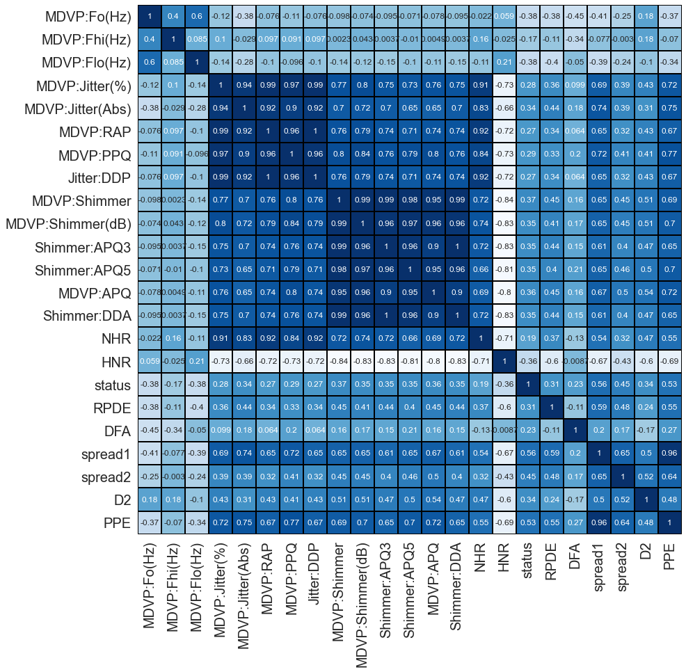

```python
corr_mat = df_orig.corr()
plt.figure(figsize = (14, 14))
sns.heatmap(corr_mat, annot_kws = {"fontsize": 12}, linewidths = 1,\
            linecolor = 'black', cmap = 'Blues', annot = True ,fmt = '.2g', cbar = False)
plt.show()
```

**Observations from Correlation Matrix:**

1. All the 5 measures of variation in fundamental frequency are highly correlated to each other. We will drop four of these and retain only one jitter parameter. NHR is also highly correlated to jitter but we will retain this feature for now.
2. All the 6 measures of variation in amplitude are highly correlated to each other. We will drop five of these and retain only one shimmer parameter.
3. spread1 and PPE are highly correlated to each other. We will drop PPE from the feature list.

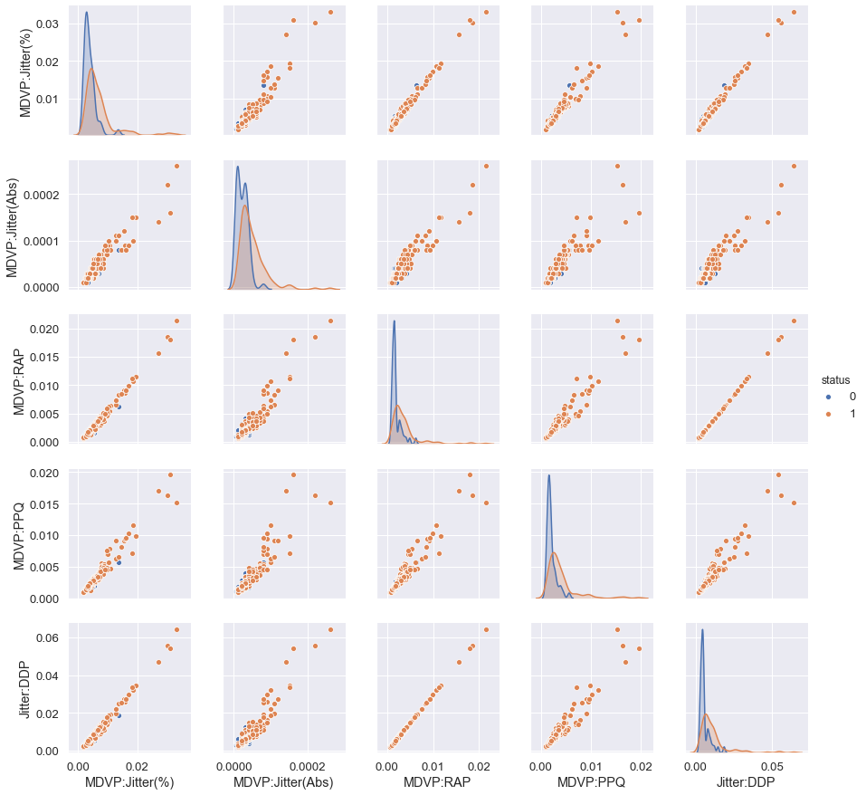

```python
# Check pair plots of all jitter features
jitt_cols = ['MDVP:Jitter(%)', 'MDVP:Jitter(Abs)', 'MDVP:RAP', 'MDVP:PPQ', 'Jitter:DDP']
sns.set(font_scale = 1.2)
sns.pairplot(df_orig, vars = jitt_cols, hue = 'status', diag_kind='kde')
plt.show()
```

**The above pairplots clearly indicate that all 5 measures of variation in fundamental frequency are highly correlated to each other as seen in the correlation matrix as well.**

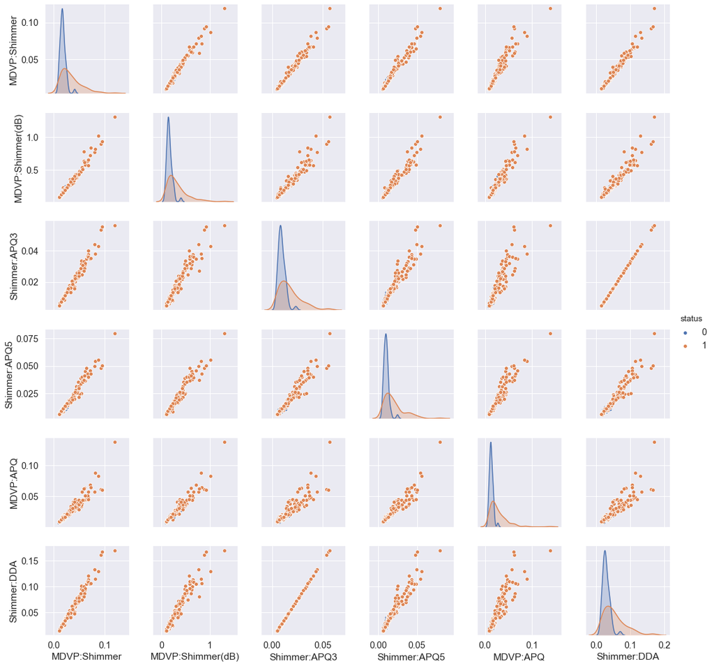

```python
# Check pair plots of all Shimmer features
shim_cols = ['MDVP:Shimmer', 'MDVP:Shimmer(dB)', 'Shimmer:APQ3', 'Shimmer:APQ5',\
             'MDVP:APQ', 'Shimmer:DDA']
sns.set(font_scale = 1.3)
sns.pairplot(df_orig, vars = shim_cols, hue = 'status', diag_kind='kde')
plt.show()
```

**The above pairplots clearly indicate that all 6 measures of variation in amplitude are highly correlated to each other as seen in the correlation matrix as well.**

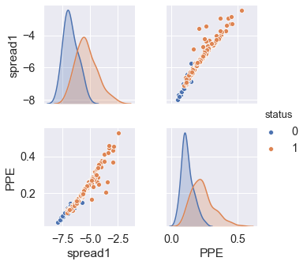

```python
# Check pair plots between spread1 and PPE
spr1_PPE_cols = ['spread1', 'PPE']
sns.set(font_scale = 1.3)
sns.pairplot(df_orig, vars = spr1_PPE_cols, hue = 'status', diag_kind='kde')
plt.show()
```

**PPE and spread1 are seen to be highly correlated to each other from the above plots.**

```python
# Drop four jitter features and retain only MDVP:Jitter(Abs).
jitt_cols_drop = ['MDVP:Jitter(%)', 'MDVP:RAP', 'MDVP:PPQ', 'Jitter:DDP']
df_orig.drop(columns = jitt_cols_drop, inplace = True)

# Drop five Shimmer features and retain only MDVP:Shimmer.
shim_cols_drop = ['MDVP:Shimmer(dB)', 'Shimmer:APQ3', 'Shimmer:APQ5',\
             'MDVP:APQ', 'Shimmer:DDA']
df_orig.drop(columns = shim_cols_drop, inplace = True)

# Drop PPE from the feature list.
df_orig.drop(columns = ['PPE'], inplace = True)
```

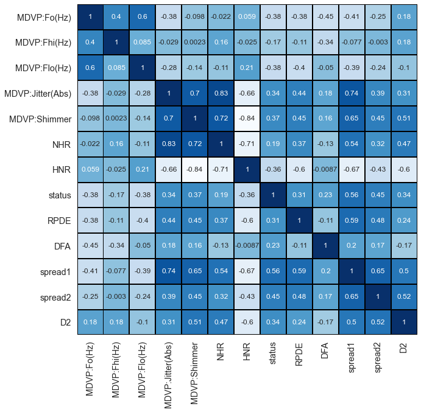

```python
# Re-plot correlation matrix of the updated dataframe
corr_mat = df_orig.corr()
plt.figure(figsize = (10, 10))
sns.heatmap(corr_mat, annot_kws = {"fontsize": 12}, linewidths = 1,\
            linecolor = 'black', cmap = 'Blues', annot = True ,fmt = '.2g', cbar = False)
plt.show()
```

**With the updated data frame, there are no two features with correlation greater than 0.9 now.**

## Pairplots

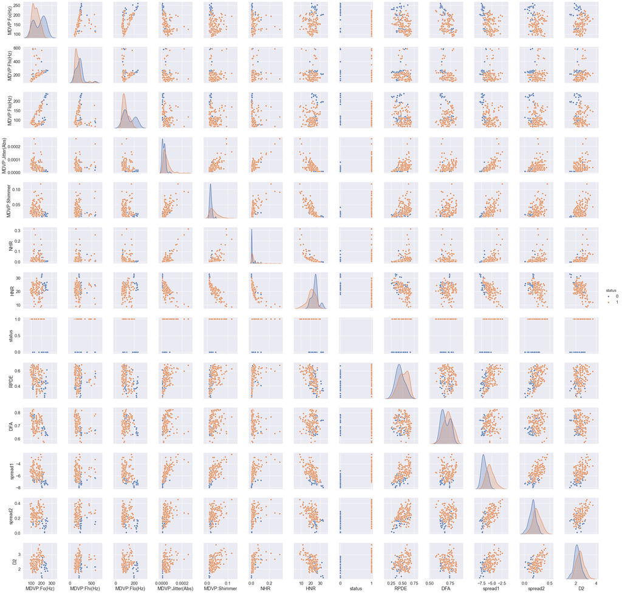

```python
sns.set(font_scale = 1.5)
sns.pairplot(df_orig, hue = 'status', diag_kind='kde')
plt.show()
```

## Statistics of numeric predictors

### Distribution and box plots of Numeric predictors

```python
# Define name of output variable
out_var = 'status'

# Get list of numeric columns and remove response variable
numer_cols = list(df_orig.select_dtypes(include = np.number).columns)
numer_cols.remove(out_var)

pos_cl_df = df_orig[df_orig[out_var] == 1] # Trimmed dataframe with only positive class samples
neg_cl_df = df_orig[df_orig[out_var] == 0] # Trimmed dataframe with only negative class samples
```

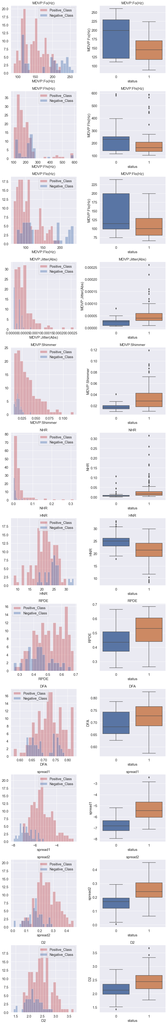

```python
# Initialize figure to plot distributions and box plots of all numeric predictors
num_cols = 2 # Number of columns to plot in the figure
num_rows = len(numer_cols) # Number of rows to plot in the figure
fig = plt.figure(figsize = (10, (5 * num_rows)))

# Plot distribution and boxplots for all numeric perdictors
for ind, val in enumerate(numer_cols):

    sns.set(font_scale = 1.3)
    ax = plt.subplot(num_rows, num_cols ,((2 * ind) + 1))
    sns.distplot(pos_cl_df[val], bins = 20, kde = False, label = 'Positive_Class', color = 'r')
    sns.distplot(neg_cl_df[val], bins = 20, kde = False, label = 'Negative_Class', color = 'b')
    ax.set_title(val, fontsize = 15)
    ax.legend()

    ax = plt.subplot(num_rows, num_cols ,((2 * ind) + 2))
    sns.boxplot(x = out_var, y = val, data = df_orig)
    ax.set_title(val, fontsize = 15)

plt.tight_layout()
plt.show()
```

**Summary of Plots above:**

### Five-Point Summary, outliers and skew of numerical attributes

```python
fps_out_skew(df_orig, numer_cols)
```

|  | Min | Q1 | Q2 | Q3 | Max | IQR | skew | out_low | out_high | out_tot |
| --- | --- | --- | --- | --- | --- | --- | --- | --- | --- | --- |
| MDVP:Fo(Hz) | 8.8333e+01 | 1.1757e+02 | 1.4879e+02 | 1.8277e+02 | 260.1050 | 6.5197e+01 | 0.5872 | 0 | 0 | 0 |
| MDVP:Fhi(Hz) | 1.0214e+02 | 1.3486e+02 | 1.7583e+02 | 2.2421e+02 | 592.0300 | 8.9343e+01 | 2.5225 | 0 | 11 | 11 |
| MDVP:Flo(Hz) | 6.5476e+01 | 8.4291e+01 | 1.0431e+02 | 1.4002e+02 | 239.1700 | 5.5728e+01 | 1.2080 | 0 | 9 | 9 |
| MDVP:Jitter(Abs) | 7.0000e-06 | 2.0000e-05 | 3.0000e-05 | 6.0000e-05 | 0.0003 | 4.0000e-05 | 2.6287 | 0 | 6 | 6 |
| MDVP:Shimmer | 9.5400e-03 | 1.6505e-02 | 2.2970e-02 | 3.7885e-02 | 0.1191 | 2.1380e-02 | 1.6536 | 0 | 8 | 8 |
| NHR | 6.5000e-04 | 5.9250e-03 | 1.1660e-02 | 2.5640e-02 | 0.3148 | 1.9715e-02 | 4.1882 | 0 | 19 | 19 |
| HNR | 8.4410e+00 | 1.9198e+01 | 2.2085e+01 | 2.5075e+01 | 33.0470 | 5.8775e+00 | -0.5104 | 3 | 0 | 3 |
| RPDE | 2.5657e-01 | 4.2131e-01 | 4.9595e-01 | 5.8756e-01 | 0.6852 | 1.6626e-01 | -0.1423 | 0 | 0 | 0 |
| DFA | 5.7428e-01 | 6.7476e-01 | 7.2225e-01 | 7.6188e-01 | 0.8253 | 8.7124e-02 | -0.0330 | 0 | 0 | 0 |
| spread1 | -7.9650e+00 | -6.4501e+00 | -5.7209e+00 | -5.0462e+00 | -2.4340 | 1.4039e+00 | 0.4288 | 0 | 4 | 4 |
| spread2 | 6.2740e-03 | 1.7435e-01 | 2.1888e-01 | 2.7923e-01 | 0.4505 | 1.0488e-01 | 0.1433 | 1 | 1 | 2 |
| D2 | 1.4233e+00 | 2.0991e+00 | 2.3615e+00 | 2.6365e+00 | 3.6712 | 5.3733e-01 | 0.4271 | 0 | 1 | 1 |

**From the table above, we can see that there are outliers in the following variables:**

```
* MDVP:Fhi(Hz)
* MDVP:Flo(Hz)
* MDVP:Jitter(Abs)
* MDVP:Shimmer
* NHR
* HNR
* spread1
* spread2
* D2
```

**The following features have high positive / right skew:**

```
* MDVP:Fhi(Hz)
* MDVP:Flo(Hz)
* MDVP:Jitter(Abs)
* MDVP:Shimmer
* NHR
```

**The rest of the features have low or moderate skew.**

## Target column distribution

- **Positive class** is defined as the class when an individual has Parkinson's disease. (status = 1).
- **Negative class** is defined as the class when when an individual doesn't have Parkinson's disease. (status = 0).

### Count plot of target column

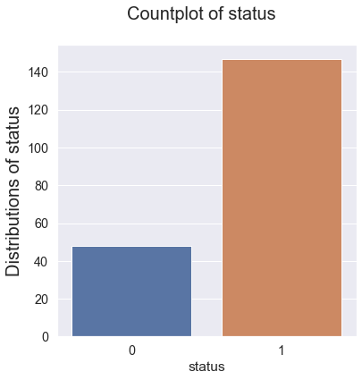

```python
fig = plt.figure(figsize = (6, 6))
fig.suptitle('Countplot of status', fontsize = 20)

ax1 = plt.subplot(1,1,1)
sns.countplot(df_orig[out_var])
ax1.set_ylabel('Distributions of status', fontsize = 20)
plt.show()
```

### Value counts of target column

```python
# Compute distribution of positive and negative classes in full dataset
APC_FDS = df_orig[out_var].value_counts()[1] # Count of Actual Positives: Full dataset
ANC_FDS = df_orig[out_var].value_counts()[0] # Count of Actual Negatives: Full dataset

print("Full Dataset")
print("============")
print("Number of individuals who have Parkinsons disease: %d (%0.2f %%)"\
      %(APC_FDS, (100 * APC_FDS / (APC_FDS + ANC_FDS))))
print("Number of individuals who don't have Parkinsons disease: %d (%0.2f %%)"\
      %(ANC_FDS, (100 * ANC_FDS / (APC_FDS + ANC_FDS))))
```

```
Full Dataset
============
Number of individuals who have Parkinsons disease: 147 (75.38 %)
Number of individuals who don't have Parkinsons disease: 48 (24.62 %)
```

**The above data indicates that this is a slightly imbalanced dataset. Around 75% of the samples belong to the positive class and the remaining 25% of the samples belong to the negative class.**

# Generate Train / Test sets

- The dataset will now be split into train and test sets in the ratio 70:30.
- Splitting will be stratified using the output variable to maintain the same class distribution in the train and test sets as it is in the original dataset.

```python
X = df_orig.drop(columns = 'status')
y = df_orig['status']

# Generate train and test datasets
# Training set : test set ratio = 70 : 30, splitting is stratified with the response variable.
X_train, X_test, y_train, y_test = train_test_split(X, y, test_size = 0.3,\
                                                          stratify = y, random_state=0)
print("X_train.shape: {}" .format(X_train.shape))
print("y_train.shape: {}" .format(y_train.shape))
print("X_test.shape: {}" .format(X_test.shape))
print("y_test.shape: {}" .format(y_test.shape))
```

```
X_train.shape: (136, 12)
y_train.shape: (136,)
X_test.shape: (59, 12)
y_test.shape: (59,)
```

## Positive and Negative class summary

```python
# Compute distribution of positive and negative classes in full dataset
APC_FDS = df_orig[out_var].value_counts()[1] # Count of Actual Positives: Full dataset
ANC_FDS = df_orig[out_var].value_counts()[0] # Count of Actual Negatives: Full dataset

# Compute distribution of positive and negative classes in train and test sets
APC_TrS = y_train.value_counts()[1] # Count of Actual Positives: Training Data set
ANC_TrS = y_train.value_counts()[0] # Count of Actual Negatives: Training Data set
APC_TeS = y_test.value_counts()[1] # Count of Actual Positives: Test Data set
ANC_TeS = y_test.value_counts()[0] # Count of Actual Negatives: Test Data set

print("Full Dataset")
print("============")
print("Actual positive count: %d (%0.2f %%)"\
      %(APC_FDS, (100 * APC_FDS / (APC_FDS + ANC_FDS))))
print("Actual Negative count: %d (%0.2f %%)"\
      %(ANC_FDS, (100 * ANC_FDS / (APC_FDS + ANC_FDS))))
print('')

print("Training Set")
print("============")
print("Actual positive count: %d (%0.2f %%)"\
      %(APC_TrS, (100 * APC_TrS / (APC_TrS + ANC_TrS))))
print("Actual Negative count: %d (%0.2f %%)"\
      %(ANC_TrS, (100 * ANC_TrS / (APC_TrS + ANC_TrS))))
print('')

print("Test Set")
print("========")
print("Actual positive count: %d (%0.2f %%)"\
      %(APC_TeS, (100 * APC_TeS / (APC_TeS + ANC_TeS))))
print("Actual Negative count: %d (%0.2f %%)"\
      %(ANC_TeS, (100 * ANC_TeS / (APC_TeS + ANC_TeS))))
```

```
Full Dataset
============
Actual positive count: 147 (75.38 %)
Actual Negative count: 48 (24.62 %)

Training Set
============
Actual positive count: 103 (75.74 %)
Actual Negative count: 33 (24.26 %)

Test Set
========
Actual positive count: 44 (74.58 %)
Actual Negative count: 15 (25.42 %)
```

**The above data indicates that the train and test splits have been done while maintaining the positive to negative class ratio.**

# Models - Fit and Evaluate

- In this section, we fit all the models defined in **Init Classifier** above. Multiple metrics evaluated on the training and test sets are printed. Next, confusion matrices, ROC plots and precision - recall plots are plotted.
- Summary of all models is provided after the precision - recall plots.

## Initialize fitted Classifiers

```python
# Define initial list of fitted classifiers with 'None' values
clfs_fit = [None for ind in range(len(clf_define()))]
```

## Initialize grid / random search parameters

```python
# Define list of all classifiers
clfs = clf_define()

# Define scaler to use on all numeric columns
sc1 = MinMaxScaler()
sc2 = StandardScaler()
sc3 = RobustScaler()
sc4 = None
# scaler = [sc1 for ind in range(len(clfs))]
# Apply minmaxscaler to all models other than tree based models
scaler = [sc1, sc1, sc1, sc1, sc1, sc1, sc1, sc4, sc4, sc4, sc4, sc4]

# Define type of cross-validation to perform for each classifier
    # 0: Dont run any hyperparameter search (Use this only if the classifier has been fit already)
    # 1: Run Grid Search CV
    # 2: Run Randomized Search CV
cv_type = [1 for ind in range(len(clfs))]
#cv_type = [0, 0, 0, 0, 0, 0, 0, 0, 1, 0, 0, 0]

# Define number of parameter settings to sample while running Randomized Search CV.
num_iter = [10 for ind in range(len(clfs))]

# Define number of cross-validations to perform for each classifier
num_cv = [5 for ind in range(len(clfs))]

# Define whether to perform coarse of fine search for each classifier
    # 0: Perform coarse search, use 'param_grid_coarse' from the classifier dictionary
    # 1: Perform fine search, use 'param_grid_fine' from the classifier dictionary
#cf = [0 for ind in range(len(clfs))]
cf = [0, 0, 0, 0, 0, 0, 0, 0, 0, 1, 1, 1]
```

## Run grid / random search CV

```python
# Run grid / random search CV based on the parameters set above
clfs_fit = model_fit(clfs, clfs_fit, X_train, y_train, scaler, cv_type, cf, num_cv, num_iter)
```

```
Fitting Classifier 0...., Fitting Completed. Elapsed time = 1.02 seconds
Fitting Classifier 1...., Fitting Completed. Elapsed time = 0.92 seconds
Fitting Classifier 2...., Fitting Completed. Elapsed time = 0.06 seconds
Fitting Classifier 3...., Fitting Completed. Elapsed time = 1.86 seconds
Fitting Classifier 4...., Fitting Completed. Elapsed time = 1.11 seconds
Fitting Classifier 5...., Fitting Completed. Elapsed time = 10.31 seconds
Fitting Classifier 6...., Fitting Completed. Elapsed time = 3.02 seconds
Fitting Classifier 7...., Fitting Completed. Elapsed time = 6.95 seconds
Fitting Classifier 8...., Fitting Completed. Elapsed time = 23.59 seconds
Fitting Classifier 9...., Fitting Completed. Elapsed time = 50.59 seconds
Fitting Classifier 10...., Fitting Completed. Elapsed time = 88.41 seconds
Fitting Classifier 11...., Fitting Completed. Elapsed time = 38.67 seconds
```

```python
# This section is for iterating on the grid / random search CV process.

# clf_ind = 5
# cv_df = cv_results_summary(clfs_fit, clf_ind)

# param_1 = 'param_adaboostclassifier__n_estimators'
# param_2 = 'param_svc__C'
# param_3 = 'param_svc__gamma'

# cv_df = cv_df[cv_df[param_1] == 100]
# cv_df = cv_df[cv_df[param_2] == 1]
# display(cv_df)

# xaxis = cv_df[param_1]
# yaxis_1 = cv_df['mean_train_score']
# yaxis_2 = cv_df['mean_test_score']
# plt.figure(figsize = (8, 8))
# plt.plot(xaxis, yaxis_1, 'b-*', label = 'Training_Set')
# plt.plot(xaxis, yaxis_2, 'r-*', label = 'Test_Set')
# plt.xscale('log')
# plt.legend(loc = 'best')
# plt.show()

# cv_df.sort_values(by = 'mean_train_score', ascending = False)
# cv_df.sort_values(by = 'rank_test_score')
# cv_df.sort_values(by = param_1)
# clfs_fit[clf_ind].best_estimator_
```

## Evaluate Models

This section will evaluate all the models that have been fit above using grid / random search.

```python
# List of output parameters that will be evaluated for each classifier
# Classifier Accuracy, Precision, Recall, F1-Score
# AUC (Area Under ROC curve)
# APS (Average Precsion Score, area under precision - recall curve)
param_names = ['Class_Acc(%)', 'Precision', 'Recall', 'F1-Score', 'AUC', 'APS']

ms_train, ms_test_set, ms_ss = model_eval(clfs, clfs_fit, param_names,\
                                          X_train, y_train, X_test, y_test, True, True, True)
```

```
Classification_Accuracy_Summary
===============================
```

|  | CV_Score(%) | Train_Score(%) | Test_Score(%) |
| --- | --- | --- | --- |
| Logistic_Regression_Without_Class_Weights | 85.2910 | 85.2941 | 81.3559 |
| Logistic_Regression_With_Balanced_Class_Weights | 83.8889 | 86.0294 | 69.4915 |
| Gaussian_Naive_Bayes | 78.6772 | 79.4118 | 66.1017 |
| K_Nearest_Neighbors | 90.4233 | 100.0000 | 93.2203 |
| Linear_SVC | 84.5767 | 84.5588 | 83.0508 |
| SVM_With_Poly_Kernel | 87.5397 | 90.4412 | 84.7458 |
| SVM_With_RBF_Kernel | 90.4497 | 100.0000 | 96.6102 |
| Decision_Tree_Classifier | 89.7090 | 100.0000 | 83.0508 |
| Bagging_Classifier | 90.4497 | 100.0000 | 83.0508 |
| Random_Forest_Classifer | 92.6455 | 100.0000 | 86.4407 |
| Adaptive_Boosting_Classifier | 90.4497 | 100.0000 | 94.9153 |
| Gradient_Boosting_Classifier | 91.9312 | 100.0000 | 93.2203 |

```
Summary of all models on training set
=====================================
```

|  | Class_Acc(%) | Precision | Recall | F1-Score | AUC | APS |
| --- | --- | --- | --- | --- | --- | --- |
| Logistic_Regression_Without_Class_Weights | 85.2941 | 0.8547 | 0.9709 | 0.9091 | 0.9300 | 0.9768 |
| Logistic_Regression_With_Balanced_Class_Weights | 86.0294 | 0.9667 | 0.8447 | 0.9016 | 0.9453 | 0.9831 |
| Gaussian_Naive_Bayes | 79.4118 | 0.9213 | 0.7961 | 0.8542 | 0.9014 | 0.9686 |
| K_Nearest_Neighbors | 100.0000 | 1.0000 | 1.0000 | 1.0000 | 1.0000 | 1.0000 |
| Linear_SVC | 84.5588 | 0.8361 | 0.9903 | 0.9067 | 0.8991 | 0.9682 |
| SVM_With_Poly_Kernel | 90.4412 | 0.9091 | 0.9709 | 0.9390 | 0.9735 | 0.9910 |
| SVM_With_RBF_Kernel | 100.0000 | 1.0000 | 1.0000 | 1.0000 | 1.0000 | 1.0000 |
| Decision_Tree_Classifier | 100.0000 | 1.0000 | 1.0000 | 1.0000 | 1.0000 | 1.0000 |
| Bagging_Classifier | 100.0000 | 1.0000 | 1.0000 | 1.0000 | 1.0000 | 1.0000 |
| Random_Forest_Classifer | 100.0000 | 1.0000 | 1.0000 | 1.0000 | 1.0000 | 1.0000 |
| Adaptive_Boosting_Classifier | 100.0000 | 1.0000 | 1.0000 | 1.0000 | 1.0000 | 1.0000 |
| Gradient_Boosting_Classifier | 100.0000 | 1.0000 | 1.0000 | 1.0000 | 1.0000 | 1.0000 |

```
Summary of all models on test set
=====================================
```

|  | Class_Acc(%) | Precision | Recall | F1-Score | AUC | APS |
| --- | --- | --- | --- | --- | --- | --- |
| Logistic_Regression_Without_Class_Weights | 81.3559 | 0.8837 | 0.8636 | 0.8736 | 0.8652 | 0.9506 |
| Logistic_Regression_With_Balanced_Class_Weights | 69.4915 | 0.9333 | 0.6364 | 0.7568 | 0.8742 | 0.9556 |
| Gaussian_Naive_Bayes | 66.1017 | 0.8529 | 0.6591 | 0.7436 | 0.8242 | 0.9265 |
| K_Nearest_Neighbors | 93.2203 | 0.9762 | 0.9318 | 0.9535 | 0.9326 | 0.9605 |
| Linear_SVC | 83.0508 | 0.8400 | 0.9545 | 0.8936 | 0.8576 | 0.9492 |
| SVM_With_Poly_Kernel | 84.7458 | 0.9070 | 0.8864 | 0.8966 | 0.9485 | 0.9819 |
| SVM_With_RBF_Kernel | 96.6102 | 0.9773 | 0.9773 | 0.9773 | 0.9955 | 0.9984 |
| Decision_Tree_Classifier | 83.0508 | 0.9250 | 0.8409 | 0.8810 | 0.8205 | 0.8965 |
| Bagging_Classifier | 83.0508 | 0.9048 | 0.8636 | 0.8837 | 0.9015 | 0.9653 |
| Random_Forest_Classifer | 86.4407 | 0.9091 | 0.9091 | 0.9091 | 0.9250 | 0.9721 |
| Adaptive_Boosting_Classifier | 94.9153 | 0.9362 | 1.0000 | 0.9670 | 0.9697 | 0.9895 |
| Gradient_Boosting_Classifier | 93.2203 | 0.9545 | 0.9545 | 0.9545 | 0.9455 | 0.9774 |

## Confustion Matrices - Test Set

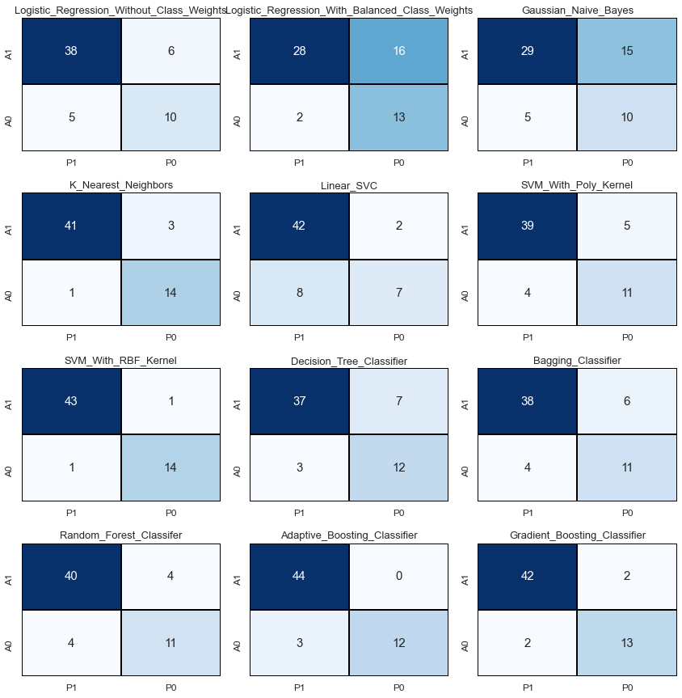

```python
plot_conf_mat(clfs, clfs_fit, X_test, y_test, 3)
```

## ROC plots - Test Set

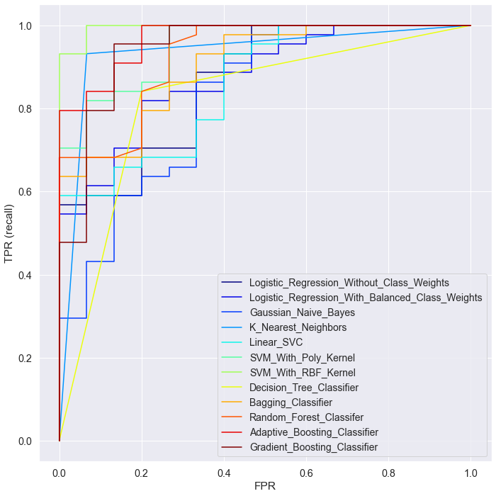

```python
plot_roc_curves(clfs, clfs_fit, X_test, y_test)
```

## Precision - Recall plots - Test Set

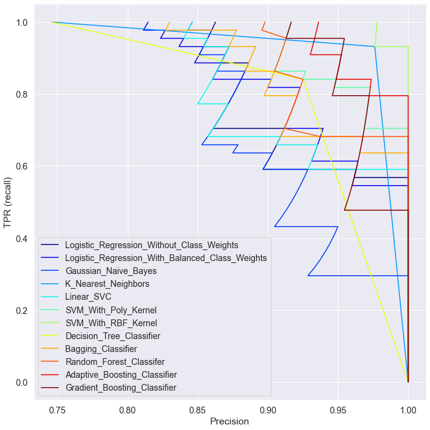

```python
plot_prec_rec_curves(clfs, clfs_fit, X_test, y_test)
```

## Performance Summary of all models

- **Logistic_Regression_With_Default_Settings:** Logistic regression classifier achieves a mean training set score of 85% and a mean CV score of 85%. Other models are able to achieve better accuracy on the training set which indicates that the logistic regression model has higher bias and is underfitting the data set. In other words, the linear model is not complex enough to fit this data set. Test set accuracy is around 81%
- **Linear Support Vector Classifier:** Performance of the linear SVC classifier is also very similar to the logistic regression classifier with mean train set / CV score of 84.5%. Test set accuracy is marginally better at 83%.
- **Logistic_Regression_With_Balanced_Class_Weigths:** With balanced class weights, the logistic regression model performs similarly w.r.t mean train set / CV scores but performs very poorly on the test set. Since this data set is only moderately imbalanced, using balanced class weigths is not a good option in this case from a generalization perspective.
- **Gaussian_Naive_Bayes:** This classifier performs worse than logistic regression w.r.t mean training set / CV scores because of the strong independence assumptions that the model makes. Test set accuracy is very poor at only 66%.
- **KNN classifier:** Based on the grid search CV results, the best choice of n_neighbors is 1. For this choice of n, the mean training set score is 100%, while the mean CV score is only 90%. This clearly indicates that we are overfitting the data set (low bias, high variance). However, larger values of n yield even lower values for the mean CV score. Hence, we stick with n = 1. The only way to improve the mean CV score in this case would be to increase the size of the training set. Test set accuracy is very good at 93.22%.
- **SVM with Poly Kernel:** Best CV score for SVM with poly kernel is obtained for degree = 3, C = 1 and gamma = 1. Higher order polynomials perform better on the mean train score but worse on the mean CV score leading to overfitting. Test set accuracy with the best hyperparameter choice for poly kernel is only about 85%, which is much worse than the KNN classifier.
- **SVM with RBF Kernel:** SVM with RBF kernel (best hyperparameters: C = 100, gamma = 5) gives very similar results for mean train set score (100%) and mean CV score (90%) as compared to the KNN classifier. Again, this is a high variance situation which can be reduced only if a larger dataset size is used. Test set accuracy of 96.6% is the best amongst all classifiers.
- **Tree-Based and Ensemble Classifiers:** All tree-based classifiers (Decision tree and ensemble classifiers - Bagging, Random Forest, Adaptive Boosting, Gradient Boosting) achieve 100% mean classification accuracy on the training set and around 90% mean CV score. This is similar to the performance of the KNN and SVM with RBF kernel classifiers. The two boosting classifiers achieve around 93 to 94% accuracy on the test set. However, the decision tree, bagging classifier and random forest classifier achieve only around 83% to 85% accuracy on the test set.</b>
- **Overall taking all classifiers into account, the SVM classifier with RBF kernel performs the best of the lot, achieving 90% mean CV score and 96.6% test score.**

## Feature Importances

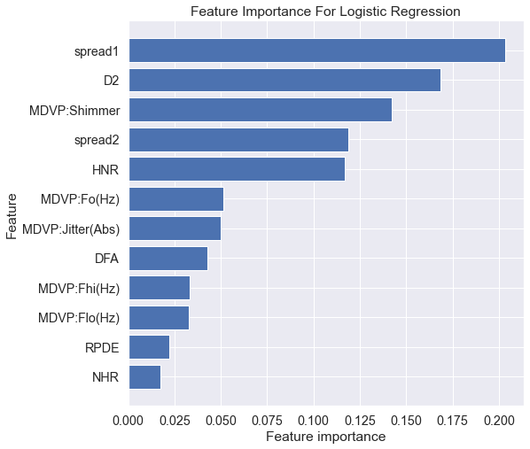

```python
# Feature importances for logistic regression with balanced class weights
# Since all the features are scaled to [0, 1] range, we can use the coefficients from
# the logistic regression classifier to assess the feature importances.
# The feature importances here are obtained by dividing the absolute value of each coefficient
# by the sum of the absolute values of all coefficients. This provides the relative importance
# of each feature.
ind = 0
clf_feat_imp = np.squeeze(np.abs(clfs_fit[ind].best_estimator_.steps[1][1].coef_) /\
                          np.sum(np.abs(clfs_fit[ind].best_estimator_.steps[1][1].coef_)))
feat_imp_df = pd.DataFrame(clf_feat_imp, columns = ['Feat_Imp'], index = X_train.columns)
feat_imp_df.sort_values(by = 'Feat_Imp', inplace = True)
plt.figure(figsize = (8, 8))
plt.barh(feat_imp_df.index, feat_imp_df['Feat_Imp'] , align='center')
plt.xlabel("Feature importance")
plt.ylabel("Feature")
plt.title("Feature Importance For Logistic Regression")
plt.show()
```

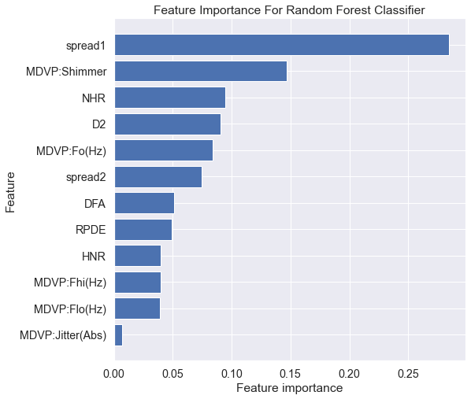

```python
# Random Forest Classifier
ind = 9
clf_feat_imp = clfs_fit[ind].best_estimator_.steps[1][1].feature_importances_
feat_imp_df = pd.DataFrame(clf_feat_imp, columns = ['Feat_Imp'], index = X_train.columns)
feat_imp_df.sort_values(by = 'Feat_Imp', inplace = True)
plt.figure(figsize = (8, 8))
plt.barh(feat_imp_df.index, feat_imp_df['Feat_Imp'] , align='center')
plt.xlabel("Feature importance")
plt.ylabel("Feature")
plt.title("Feature Importance For Random Forest Classifier")
plt.show()
```

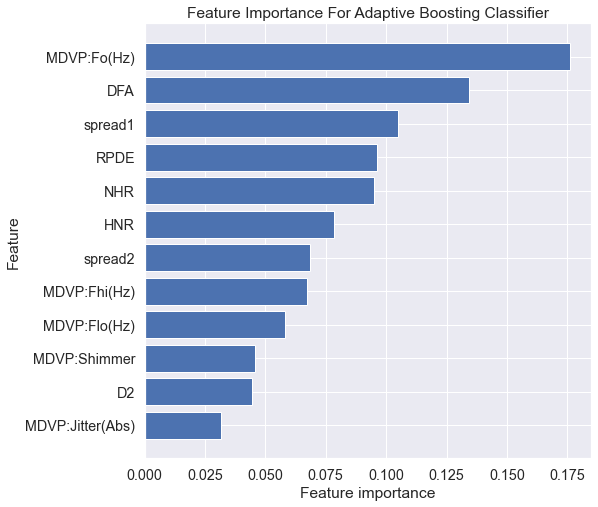

```python
# Adaptive Boosting Classifier
ind = 10
clf_feat_imp = clfs_fit[ind].best_estimator_.steps[1][1].feature_importances_
feat_imp_df = pd.DataFrame(clf_feat_imp, columns = ['Feat_Imp'], index = X_train.columns)
feat_imp_df.sort_values(by = 'Feat_Imp', inplace = True)
plt.figure(figsize = (8, 8))
plt.barh(feat_imp_df.index, feat_imp_df['Feat_Imp'] , align='center')
plt.xlabel("Feature importance")
plt.ylabel("Feature")
plt.title("Feature Importance For Adaptive Boosting Classifier")
plt.show()
```

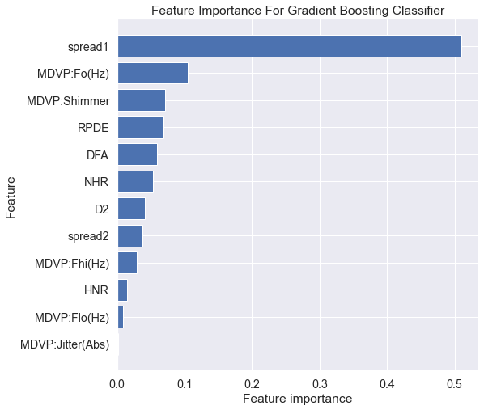

```python
# Gradient Boosting Classifier
ind = 11
clf_feat_imp = clfs_fit[ind].best_estimator_.steps[1][1].feature_importances_
feat_imp_df = pd.DataFrame(clf_feat_imp, columns = ['Feat_Imp'], index = X_train.columns)
feat_imp_df.sort_values(by = 'Feat_Imp', inplace = True)
plt.figure(figsize = (8, 8))
plt.barh(feat_imp_df.index, feat_imp_df['Feat_Imp'] , align='center')
plt.xlabel("Feature importance")
plt.ylabel("Feature")
plt.title("Feature Importance For Gradient Boosting Classifier")
plt.show()
```

# Meta-Classifier

- In this section, we will implement a meta-classifier using the StackingClassifier() function.

## Option 1:

**Base Classifiers:**

```
* k-Nearest Neighbors
* SVM with RBF Kernel
* Adaptive Boosting Classifier
```

**Stacking Classifier:**

```
* Logistic Regression
```

```python
# k-Nearest Neighbors with n_neighbors = 1 (MinMaxScaler used).
pipe_1 = clfs_fit[3].best_estimator_
# SVM classifier with RBK kernel and C = 100, gamma = 5 (MinMaxScaler used).
pipe_2 = clfs_fit[6].best_estimator_
# Adaptive Boosting classifier with n_estimators = 790. (No scaling of features)
pipe_3 = clfs_fit[10].best_estimator_

estimators = [('p1', pipe_1), ('p2', pipe_2), ('p3', pipe_3)]
final_estimator = LogisticRegression(solver = 'liblinear')

sclf = StackingClassifier(estimators = estimators, final_estimator = final_estimator)
sclf_acc_op1 = 100 * sclf.fit(X_train, y_train).score(X_test, y_test)
print("Classification accuracy on test set using stacking classifier with option 1 is %0.2f %%"\
      %sclf_acc_op1)
```

```
Classification accuracy on test set using stacking classifier with option 1 is 96.61 %
```

**This meta classifier achieves the same classification accuracy on the test set as the stand-alone SVM classifier with RBF kernel.**

## Option 2:

**Base Classifiers:**

```
* Logistic Regression Classifier.
* Gaussian Naive Bayes Classifier.
* Decision Tree Classifier.
```

**Stacking Classifier:**

```
* SVM classifier with RBF Kernel.
```

```python
# Logistic regression classifier with C = 5 (MinMaxScaler used).
pipe_1 = clfs_fit[0].best_estimator_
# Gaussian Naive Bayes classifier (MinMaxScaler used).
pipe_2 = clfs_fit[2].best_estimator_
# Decision tree classifier with criterion = 'entropy', max_depth = 6.
pipe_3 = clfs_fit[7].best_estimator_

estimators = [('p1', pipe_1), ('p2', pipe_2), ('p3', pipe_3)]
final_estimator = SVC()

sclf = StackingClassifier(estimators = estimators, final_estimator = final_estimator)
sclf_acc_op2 = 100 * sclf.fit(X_train, y_train).score(X_test, y_test)
print("Classification accuracy on test set using stacking classifier with option 2 is %0.2f %%"\
      %sclf_acc_op2)
```

```
Classification accuracy on test set using stacking classifier with option 2 is 83.05 %
```

**Once again, this meta classifier achieves the same classification accuracy on the test set as the stand-alone decision tree classifier.**